**EL USO, PREFERENCIA DE DISPOSITIVOS ELECTRÓNICOS Y SU IMPACTO EN LA PRODUCTIVIDAD Y EL DESEMPEÑO ACADÉMICO SEGÚN EL PERFIL DE LOS ALUMNOS DE PREGRADO DE LA UNIVERSIDAD DE INGENIERÍA Y TECNOLOGÍA EN EL PERíODO 2023-I.**

# **Introducción**

## **Importancia y Justificación**

El desempeño académico de los estudiantes universitarios puede verse influenciados por la preferencia y el uso de ciertos dispositivos electrónicos. Este estudio se centra en identificar y analizar el impacto que produce los dispositivos electrónicos en el desempeño académico, de esta manera recolectar información relevante para su correcto análisis.

## **Relevancia**

En los últimos años la presencia de los dispositivos electrónicos en el sector de la educación ha ido en aumento por lo que es crucial realizar un análisis sobre como su uso, preferencia e impacto de los dispositivos electrónicos se relaciona con la productividad y el desempeño académico de los estudiantes de la Universidad de Ingeniería y Tecnología. Este estudio proporcionara información relevante a la universidad ya sea para promover o mejor el correcto uso de estos dispositivos en el proceso de aprendizaje. De igual manera estos resultados podrán servir como base para el desarrollo de políticas y programas que promuevan el uso responsable y efectivo de los dispositivos electrónicos en alumnos de pregrado.

## **Objetivos**

### **Objetivo general**

Determinar el impacto del uso de dispositivos electrónicos en la productividad académica de los estudiantes de pregrado de la Universidad de Ingeniería y Tecnología.

### **Objetivo especifico**

- Determinar las principales aplicaciones que utilizan los estudiantes según su perfil académico en la Universidad de Ingeniería y Tecnología y su relación con el desarrollo académico.
- Comparar la frecuencia del uso de los dispositivos electrónicos con los promedios ponderados de los estudiantes de la Universidad de Ingeniería y Tecnología.
- Verificar la influencia de la cantidad de dispositivos electrónicos en el desempeño académico en los estudiantes de la Universidad de Ingeniería y Tecnología.
- Validar la satisfacción de los estudiantes al utilizar dispositivos electrónicos en las distintas áreas académicas y como se relaciona con las notas obtenidas.
- Contrastar la relación entre la marca del dispositivo que usa con mayor frecuencia según el ciclo en el que se encuentra con el costo de estos equipos en el desempeño académico.

## **Contexto**

Vivimos en una era digital donde los dispositivos electrónicos desempeñan un papel fundamental en nuestra vida diaria, incluyendo el ámbito educativo. La tecnología se ha convertido en una herramienta omnipresente en la educación, y su uso adecuado puede tener un impacto significativo en el rendimiento académico de los estudiantes. En este contexto, es importante comprender cómo los estudiantes utilizan los dispositivos electrónicos, cuáles son sus preferencias y cómo estas elecciones pueden afectar su productividad y desempeño académico. El estudio se enmarca en este contexto tecnológico en constante evolución, donde se busca explorar las dinámicas y tendencias relacionadas con el uso de dispositivos electrónicos en el entorno universitario. Esto permitirá obtener información valiosa para adaptar las prácticas educativas y promover un uso efectivo de la tecnología en beneficio de los estudiantes de pregrado.

# **Datos**

## **Recolección de datos**

Se llevó a cabo la recopilación de datos mediante un muestreo aleatorio simple utilizando una encuesta electrónica realizada a través de Google Forms. La encuesta constaba de 18 variables la cual se diseñó específicamente para los estudiantes de la Universidad de Ingeniería y Tecnología. Se procuró que las preguntas fueran claras y de fácil comprensión para los encuestados, asimismo se implementaron restricciones en cada pregunta para minimizar posibles errores en las respuestas. La difusión de la encuesta se realizó a través de la virtualidad en redes sociales y presencialmente con la distribución de códigos QR en la universidad. Finalmente se evito repartir dulces o hacer sorteos para evitar que las respuestas sean condicionadas y provocar sesgo.

## **Población, muestra y muestreo**

### **Población**

Estudiantes de pregrado de la Universidad de Ingeniería y Tecnología que se encuentran cursando el período 2023-1.

### **Muestra**

El tamaño de la muestra es de 201 encuestados.

### **Muestreo**

Muestreo aleatorio simple.

## **Variables**

### a) Numéricas (8)

#### Continuas (4)

| *Variable* | *Definición* |
| --- | --- |
| PROMEDIO | Promedio ponderado de cada alumno. |
| COSTO | Precio del dispositivo que utiliza con mayor frecuencia. |
| MINUTOS | minutos al día que utilizan sus dispositivos para estudiar. |
| MAXNOTA | Máxima nota que obtuvo utilizando un dispositivo tecnológico. |

#### Discretas (4)

| *Variable* | *Definición* |
| --- | --- |
| CANAPLI | El número de aplicaciones educativas instaladas en los dispositivos electrónicos. |
| CANTDISPOSITIVOS | El número de dispositivos electrónicos que poseen para uso académico. |
| CURSOS | El número de cursos que llevo en el periodo 2022-2. |
| DÍAS | Número de días a la semana que utiliza su dispositivo con fines académicos. |

### b) Categóricas (10)

#### Ordinal (4)

| *Variable* | *Definición* |
| --- | --- |
| ORDENM | Orden de mérito. |
| CICLO | Ciclo en el que se encuentra actualmente. |
| SATISFACCIÓN | Satisfacción en los trabajos que dependen de dispositivos tecnológicos. |
| FRECUENCIA | Frecuencia con el que usan los dispositivos para fines educativos. |

#### Nominal (6)

| *Variable* | *Definición* |
| --- | --- |
| SEXO | sexo |
| CARRERA | Carrera universitaria. |
| DISPOSITIVO | Dispositivo que usa con mayor frecuencia. |
| APLICACIONES | Aplicación educativa que usa con mayor frecuencia. |
| MARCA | Marca de los dispositivos que utiliza. |
| ÁREA | Área académica en el que obtuvo mayor satisfacción. |

## **Preguntas de la encuesta**

### **Preguntas personales:**

| *Preguntas* |
| --- |
| ¿Cuál es su género? |
| ¿A qué carrera universitaria pertenece? |
| ¿En qué ciclo te encuentras? |

### **Preguntas de preferencia:**

| *Preguntas* |
| --- |
| ¿Qué dispositivo utilizas con mayor frecuencia? |
| ¿Qué aplicación educativa utilizas con mayor frecuencia? |
| ¿Qué marca de dispositivo utilizas actualmente? |
| ¿En qué área académica te ayudó más tu dispositivo tecnológico? |
| ¿Cuánto fue la nota que obtuviste en el área de estudio mencionada anteriormente? |

### **Preguntas de satisfacción:**

| *Preguntas* |
| --- |
| ¿Cuál es su orden de mérito? |
| ¿Qué tan satisfecho te encuentras con los trabajos que depende de dispositivos tecnológicos? |
| ¿Con qué frecuencia utilizas tus dispositivos tecnológicos para fines educativos? |

### **Preguntas educativas:**

| *Preguntas* |
| --- |
| ¿Cuántas aplicaciones educativas tienes instaladas? |
| ¿Cuántos dispositivos tecnológicos utilizas actualmente? |
| ¿Cuántos minutos al día utilizas tus dispositivos tecnológicos para fines educativos? |
| ¿Cuántos cursos llevó en el ciclo 2022-2? |
| ¿Número de días a la semana que utiliza su dispositivo con fines académicos? |
| ¿Cuál fue el costo aproximado del dispositivo tecnológico que utilizas mayormente para fines educativos? |
| ¿Cuál es tu promedio ponderado actualmente? |

## **Limpieza de datos**

### Consideraciones

- *Las consideraciones para eliminar observaciones fueron:*
  - Información irrelevante para nuestro estudio.
  - Información por números de NA.
  - Falta de claridad y incoherencia en la información.

### Procedimiento de limpieza

Para comenzar con la limpieza de datos es necesario instalar y leer las siguientes librerías como: **readr**, **dplyr**, **car**, **DescTools**, **raster** y **ggplot2**, estas librerías nos servirán para realizar un mejor manejo de la base de datos, variables, gráficas, descriptores estadístico, descriptores gráficos y un mejor análisis probabilista.

Una vez instalada y ejecutas las librerías procedemos a leer nuestra base de datos, el cual se encuentra en un formato **csv**, asimismo lo guardamos con el nombre de **Datos** para fines prácticos con la manipulación e interacción de variables y observaciones.

```r
Datos <- read_csv("Encuesta2023_G5.csv")
```

Luego de observar nuestra base de datos nos damos cuenta que existen dos columnas que no serán relevantes para nuestro estudio. Estas columnas son *“Marca de tiempo”* y *“Puntuación”*, por tal motivo procederemos a eliminarlas:

```r
Datos <- Datos[,c(3:20)]
```

Como siguiente paso debemos utilizar la función *names* para conocer los nombres de nuestra variables.

```r
names(Datos)
```

```
##  [1] "GENERO"                   "CARRERA"
##  [3] "DISPOSITIVOS...5"         "APLICACIONES"
##  [5] "MARCA"                    "ÁREA"
##  [7] "NOTA"                     "ORDEN DE MÉRITO"
##  [9] "CICLO"                    "SATISFACCIÓN"
## [11] "FRECUENCIA"               "CANTIDAD DE APLICACIONES"
## [13] "DISPOSITIVOS...15"        "MINUTOS"
## [15] "CURSOS"                   "COSTO"
## [17] "PROMEDIO PONDERADO"       "DÍAS"
```

Después de ejecutar la linea anterior podemos notar que existe la necesidad de modificar el nombre de algunas variables por lo que utilizamos la función **rename** para facilitar su uso y manipulación:

```r
rename(Datos,
       CANTDISPOSITIVOS = "DISPOSITIVOS...15",
       DISPOSITIVO = "DISPOSITIVOS...5",
       ORDENM = "ORDEN DE MÉRITO",
       CANAPLI = "CANTIDAD DE APLICACIONES",
       MAXNOTA = "NOTA",
       PROMEDIO = "PROMEDIO PONDERADO",
) -> Datos
```

Verificamos que los respectivos cambios se hallan aplicado:

```r
names(Datos)
```

```
##  [1] "GENERO"           "CARRERA"          "DISPOSITIVO"      "APLICACIONES"
##  [5] "MARCA"            "ÁREA"             "MAXNOTA"          "ORDENM"
##  [9] "CICLO"            "SATISFACCIÓN"     "FRECUENCIA"       "CANAPLI"
## [13] "CANTDISPOSITIVOS" "MINUTOS"          "CURSOS"           "COSTO"
## [17] "PROMEDIO"         "DÍAS"
```

A continuación verificamos si el tipo de dato son los correctos, para lo cual se guiara de la siguiente manera:

**Categórica Nominal:** GENERO, CARRERA, DISPOSITIVO, APLICACIONS, MARCA, ÁREA.

**Categórica Ordinal:** ORDENM, CICLO, SATISFACCIÓN, FRECUENCIA.

**Numéricas Discreta:** CANAPLI, CANTDISPOSITIVOS, CURSOS, DÍAS.

**Numéricas Continua:** COSTO, PROMEDIO, MAXNOTA, MINUTOS.

```r
str(Datos)
```

```
## tibble [201 x 18] (S3: tbl_df/tbl/data.frame)
##  $ GENERO          : chr [1:201] "MASCULINO" "MASCULINO" "MASCULINO" "MASCULINO" ...
##  $ CARRERA         : chr [1:201] "Ingeniería Mecatrónica" "Ingeniería Electrónica" "Ingeniería Mecatrónica" "Ingeniería Civil" ...
##  $ DISPOSITIVO     : chr [1:201] "Laptop" "Laptop" "Laptop" "Laptop" ...
##  $ APLICACIONES    : chr [1:201] "Khan Academy" "Rstudio" "MatLab" "Pycharm" ...
##  $ MARCA           : chr [1:201] "Lenovo, Samsung" "Acer" "Lenovo" "HP" ...
##  $ ÁREA            : chr [1:201] "Ciencias Generales" "Ciencias Generales" "Ciencias Generales" "Ciencias Generales" ...
##  $ MAXNOTA         : num [1:201] 19.5 19.5 17 17 16 ...
##  $ ORDENM          : chr [1:201] "Quinto superior" "Ninguno de los anteriores" "Tercio superior" "Tercio superior" ...
##  $ CICLO           : chr [1:201] "Tercero" "Cuarto" "Cuarto" "Cuarto" ...
##  $ SATISFACCIÓN    : num [1:201] 3 4 3 2 3 3 4 3 3 3 ...
##  $ FRECUENCIA      : num [1:201] 3 4 4 3 3 4 4 3 3 3 ...
##  $ CANAPLI         : num [1:201] 4 4 7 5 4 5 7 3 3 8 ...
##  $ CANTDISPOSITIVOS: num [1:201] 2 3 3 3 3 2 2 4 3 2 ...
##  $ MINUTOS         : chr [1:201] "360" "400" "360" "240" ...
##  $ CURSOS          : num [1:201] 6 4 6 6 6 5 6 4 7 5 ...
##  $ COSTO           : chr [1:201] "4000" "6000" "5000" "3500" ...
##  $ PROMEDIO        : num [1:201] 18.6 14.5 14.4 15 15.3 ...
##  $ DÍAS            : num [1:201] 5 6 7 7 4 7 7 4 7 5 ...
```

Podemos observar que las variables *CANAPLI, CANTDISPOSITIVOS, CURSOS, DÍAS* son enteros por lo que procedemos a cambiarlo.

```r
Datos$CANAPLI <- as.integer(Datos$CANAPLI)
Datos$CANTDISPOSITIVOS <- as.integer(Datos$CANTDISPOSITIVOS)
Datos$CURSOS <- as.integer(Datos$CURSOS)
Datos$DÍAS <- as.integer(Datos$DÍAS)
```

Por otra parte, se observa que las variables *SATISFACCIÓN, FRECUENCIA, ORDENM, CICLO* son factores por lo que procedemos a cambiarlo.

```r
Datos$SATISFACCIÓN <- as.factor(Datos$SATISFACCIÓN)
Datos$FRECUENCIA <- as.factor(Datos$FRECUENCIA)
Datos$ORDENM <- as.factor(Datos$ORDENM)
Datos$CICLO <- as.factor(Datos$CICLO)
```

Finalmente las variables *MINUTOS y COSTO* son numéricas por lo que se procede a realizar el cambio.

```r
Datos$MINUTOS <- as.numeric(Datos$MINUTOS)
Datos$COSTO<- as.numeric(Datos$COSTO)
```

Corroboramos que el cambio de variable se halla realizado.

```r
str(Datos) #Resumen del tipo de variable de la base de datos
```

```
## tibble [201 x 18] (S3: tbl_df/tbl/data.frame)
##  $ GENERO          : chr [1:201] "MASCULINO" "MASCULINO" "MASCULINO" "MASCULINO" ...
##  $ CARRERA         : chr [1:201] "Ingeniería Mecatrónica" "Ingeniería Electrónica" "Ingeniería Mecatrónica" "Ingeniería Civil" ...
##  $ DISPOSITIVO     : chr [1:201] "Laptop" "Laptop" "Laptop" "Laptop" ...
##  $ APLICACIONES    : chr [1:201] "Khan Academy" "Rstudio" "MatLab" "Pycharm" ...
##  $ MARCA           : chr [1:201] "Lenovo, Samsung" "Acer" "Lenovo" "HP" ...
##  $ ÁREA            : chr [1:201] "Ciencias Generales" "Ciencias Generales" "Ciencias Generales" "Ciencias Generales" ...
##  $ MAXNOTA         : num [1:201] 19.5 19.5 17 17 16 ...
##  $ ORDENM          : Factor w/ 5 levels "Decimo superior",..: 4 3 5 5 5 3 5 4 1 2 ...
##  $ CICLO           : Factor w/ 10 levels "Cuarto","Decimo",..: 10 1 1 1 1 1 1 1 1 1 ...
##  $ SATISFACCIÓN    : Factor w/ 4 levels "1","2","3","4": 3 4 3 2 3 3 4 3 3 3 ...
##  $ FRECUENCIA      : Factor w/ 4 levels "1","2","3","4": 3 4 4 3 3 4 4 3 3 3 ...
##  $ CANAPLI         : int [1:201] 4 4 7 5 4 5 7 3 3 8 ...
##  $ CANTDISPOSITIVOS: int [1:201] 2 3 3 3 3 2 2 4 3 2 ...
##  $ MINUTOS         : num [1:201] 360 400 360 240 120 120 500 120 300 180 ...
##  $ CURSOS          : int [1:201] 6 4 6 6 6 5 6 4 7 5 ...
##  $ COSTO           : num [1:201] 4000 6000 5000 3500 1300 3300 3300 4000 3700 5000 ...
##  $ PROMEDIO        : num [1:201] 18.6 14.5 14.4 15 15.3 ...
##  $ DÍAS            : int [1:201] 5 6 7 7 4 7 7 4 7 5 ...
```

Luego de lo realizado anteriormente, verificamos la cantidad de datos completos e incompletos de nuestra base de datos:

```r
sum(is.na(Datos))
```

```
## [1] 2
```

```r
sum(!is.na(Datos))
```

```
## [1] 3616
```

Asimismo la cantidad de casos completos e incompletos:

```r
sum(complete.cases(Datos))
```

```
## [1] 200
```

```r
sum(!complete.cases(Datos))
```

```
## [1] 1
```

Se observa datos atípicos y Na en nuestra base de datos por lo tanto se utilizo el criterio de **eliminación de observaciones atípicas y missing** para realizar un correcto análisis e interpretación de datos.

Para realizar la eliminaciones de observaciones que tienen por lo menos un dato faltante se realizo el siguiente código:

```r
Datos <- Datos[complete.cases(Datos), ]
```

Para realizar la eliminaciones de observaciones que tienen como costos del dispositivo tecnológico menor a 600 soles se ejecuta el siguiente código.

```r
Datos <- subset(Datos, COSTO >= 600)
```

Luego de realizar nuestra limpieza se observa que existen 193 observaciones por lo que procedemos a trabajar con ellas.

```r
summary(Datos)
```

```
##     GENERO            CARRERA          DISPOSITIVO        APLICACIONES
##  Length:193         Length:193         Length:193         Length:193
##  Class :character   Class :character   Class :character   Class :character
##  Mode  :character   Mode  :character   Mode  :character   Mode  :character
##
##
##
##
##     MARCA               ÁREA              MAXNOTA
##  Length:193         Length:193         Min.   : 1.00
##  Class :character   Class :character   1st Qu.:16.00
##  Mode  :character   Mode  :character   Median :18.00
##                                        Mean   :17.44
##                                        3rd Qu.:19.00
##                                        Max.   :20.00
##
##                        ORDENM       CICLO    SATISFACCIÓN FRECUENCIA
##  Decimo superior          :27   Cuarto :88   1:  1        1:  1
##  Medio superior           :31   Segundo:26   2: 18        2: 17
##  Ninguno de los anteriores:36   Tercero:26   3:105        3: 72
##  Quinto superior          :36   Quinto :17   4: 69        4:103
##  Tercio superior          :63   Sexto  :12
##                                 Primero: 9
##                                 (Other):15
##     CANAPLI      CANTDISPOSITIVOS    MINUTOS          CURSOS
##  Min.   :0.000   Min.   :1.000    Min.   :100.0   Min.   :1.000
##  1st Qu.:4.000   1st Qu.:2.000    1st Qu.:180.0   1st Qu.:5.000
##  Median :5.000   Median :3.000    Median :300.0   Median :6.000
##  Mean   :4.824   Mean   :2.907    Mean   :297.3   Mean   :5.715
##  3rd Qu.:6.000   3rd Qu.:3.000    3rd Qu.:380.0   3rd Qu.:6.000
##  Max.   :8.000   Max.   :6.000    Max.   :960.0   Max.   :8.000
##
##      COSTO          PROMEDIO          DÍAS
##  Min.   :  600   Min.   : 5.00   Min.   :2.000
##  1st Qu.: 2000   1st Qu.:14.33   1st Qu.:5.000
##  Median : 3200   Median :15.00   Median :7.000
##  Mean   : 3370   Mean   :15.17   Mean   :6.104
##  3rd Qu.: 4000   3rd Qu.:16.00   3rd Qu.:7.000
##  Max.   :10000   Max.   :20.00   Max.   :7.000
##
```

```r
sum(is.na(Datos))
```

```
## [1] 0
```

```r
sum(!is.na(Datos))
```

```
## [1] 3474
```

```r
sum(complete.cases(Datos))
```

```
## [1] 193
```

```r
sum(!complete.cases(Datos))
```

```
## [1] 0
```

Finalmente para terminar con la limpieza de datos procedemos a renombrar los datos de las variables **Frecuencia** y **Satisfacción**, utilizando las siguiente conversiones:

**1 = Nada**

**2 = Poco**

**3 = Regular**

**4 = Mucho**

```r
Datos$FRECUENCIA = recode(Datos$FRECUENCIA," 1 = 'Nada' ; 2 = 'Poco' ; 3 = 'Regular' ; 4 = 'Mucho' ")
Datos$SATISFACCIÓN = recode(Datos$SATISFACCIÓN," 1 = 'Nada' ; 2 = 'Poco' ; 3 = 'Regular' ; 4 = 'Mucho' ")
```

De esta manera terminamos con nuestra limpieza de datos. A partir de lo realizado anteriormente seremos capaces de realizar un mejor análisis de nuestra base de datos.

# *Descriptores*

## *Análisis 1*

*identificar las aplicaciones más utilizadas por los estudiantes de acuerdo con su perfil académico de la universidad UTEC y analizar cómo estas aplicaciones se relacionan con su desarrollo académico*

Variables que sirven para el análisis:

**Carrera universitaria**

**Genero**

**Aplicaciones que utilizan**

**Promedio ponderado**

Para identificar el perfil de los estudiantes primero realizamos un análisis entre los dispositivos que utiliza y su genero:

En la siguiente gráfica lograremos conocer cual es el dispositivo tecnológico mas utilizado tanto en varones como en mujeres.

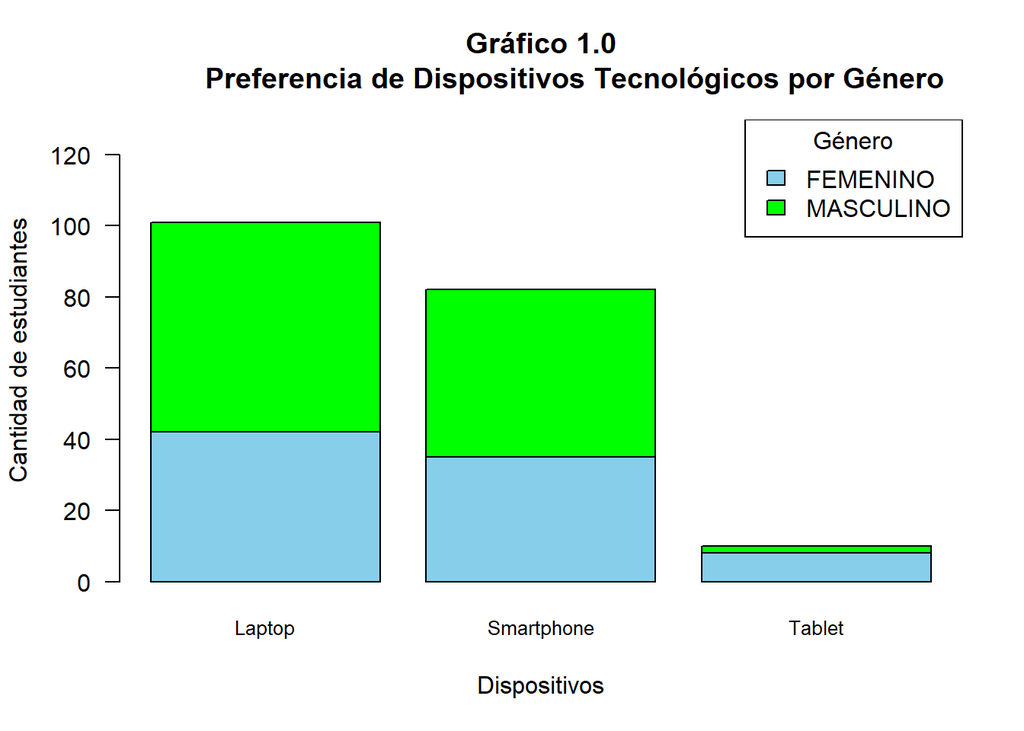

A partir de la gráfica anterior podemos observar que la mayoría de los estudiantes encuestados tanto varones como mujeres prefieren utilizar las laptops para el desarrollo de sus actividades académicas.

```r
by(Datos$PROMEDIO,Datos$DISPOSITIVO,Mode)
```

```
## Datos$DISPOSITIVO: Laptop
## [1] 15
## ------------------------------------------------------------
## Datos$DISPOSITIVO: Smartphone
## [1] 15
## ------------------------------------------------------------
## Datos$DISPOSITIVO: Tablet
## [1] 15
```

```r
by(Datos$PROMEDIO,Datos$DISPOSITIVO,Median)
```

```
## Datos$DISPOSITIVO: Laptop
## [1] 15
## ------------------------------------------------------------
## Datos$DISPOSITIVO: Smartphone
## [1] 15
## ------------------------------------------------------------
## Datos$DISPOSITIVO: Tablet
## [1] 15.25
```

La mayoría de los estudiantes tanto los que utilizan laptops, smartphone y tablet tiene un promedio ponderado de 15, lo que se puede concluir que el dispositivo tecnológico principal que utiliza para el desarrollo académico no influye en el promedio ponderado.

**Frecuencia de los estudiantes al utilizar diferentes aplicaciones**

```
##                  fi    pi
## AutoCAD          11  5.70
## Canva            35 18.13
## CLion             9  4.66
## Excel            11  5.70
## Google Classroom  3  1.55
## Kahoot            3  1.55
## Khan Academy     15  7.77
## MatLab           13  6.74
## One Note         17  8.81
## Otro             17  8.81
## Power point       6  3.11
## Pycharm           5  2.59
## Rstudio          19  9.84
## Visual Studio     7  3.63
## Word             22 11.40
```

**Gráfico de barras sobre la frecuencia de los estudiantes al utilizar aplicativos.**

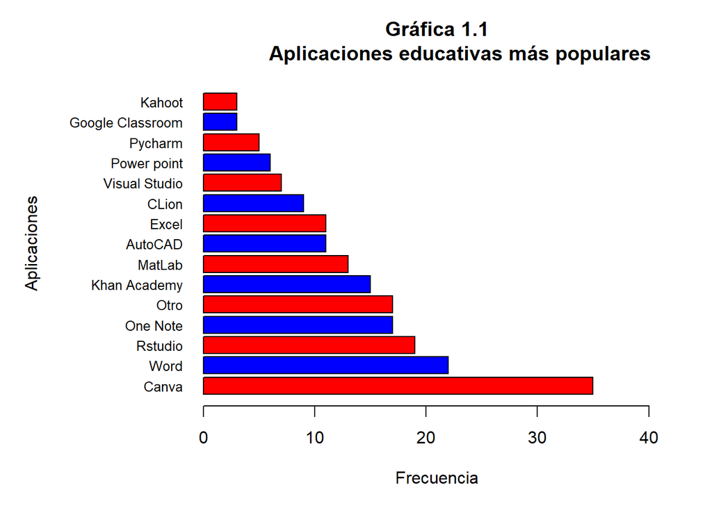

Por otra parte podemos observar que el perfil de los estudiantes se basa a la carrera a la cual pertenece por lo cual es necesario analizar los aplicativos según la carrera a la cual se estudia.

**Análisis comparativo**

```
## # A tibble: 77 x 3
## # Groups:   CARRERA, APLICACIONES [77]
##    CARRERA                APLICACIONES     n
##    <chr>                  <chr>        <int>
##  1 Ingeniería Civil       AutoCAD         10
##  2 Ingeniería Civil       Canva           10
##  3 Ingeniería Industrial  Canva            9
##  4 Ingeniería Civil       One Note         7
##  5 Ingeniería Civil       Rstudio          7
##  6 Ingeniería Civil       Word             7
##  7 Ingeniería Industrial  Rstudio          6
##  8 Ingeniería Mecatrónica Word             6
##  9 Ingeniería Civil       Khan Academy     5
## 10 Ingeniería Industrial  Excel            5
## # i 67 more rows
```

Gráfico representativo entre las aplicaciones y la carrera a la que pertenece:

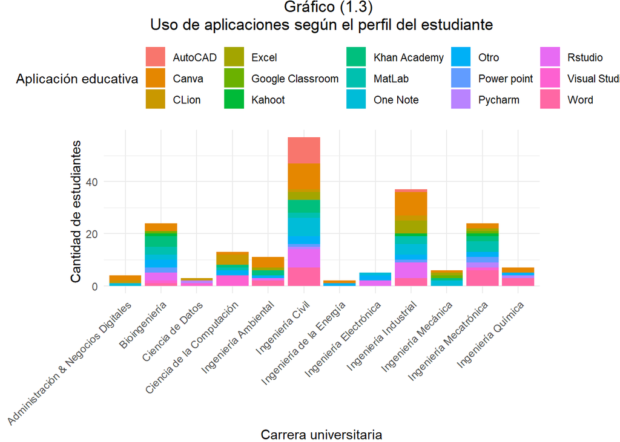

La mayoría de los estudiantes prefieren utilizar aplicativos relacionados con el diseño, productividad y organización, mientra que otra parte mínima de estudiantes optan por utilizar aplicativos de aprendizaje en linea. Por otra parte podemos observar que los estudiantes de Ingeniería civil e industrial optan por utilizar gran parte de todos los aplicativos. Asimismo los alumnos de la carrera de ciencia de datos y ingeniería de la energía, son los que utilizan en menor frecuencia todos los aplicativos.

Una vez analizada los aplicativos según el perfil de los estudiantes procedemos a realizar una análisis entre los aplicativos que se utiliza y como estos influyen en el promedio ponderado. Para lo cual realizamos un gráfico de caja para inferir sobre la dispersión, ubicación y simetría de los promedios ponderados de acuerdo al aplicativo que utilizan.

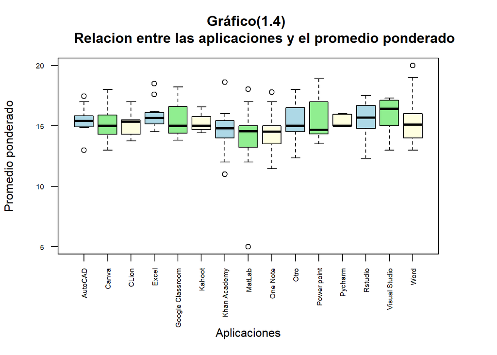

Como podemos observar en el gráfico de cajas existe la presencia de datos atípicos por lo que procedemos a trabajar con la mediana ya que en estos casos es el mejor indicador.

```
## Datos$APLICACIONES: AutoCAD
## [1] 15.4
## ------------------------------------------------------------
## Datos$APLICACIONES: Canva
## [1] 15
## ------------------------------------------------------------
## Datos$APLICACIONES: CLion
## [1] 15.34
## ------------------------------------------------------------
## Datos$APLICACIONES: Excel
## [1] 15.65
## ------------------------------------------------------------
## Datos$APLICACIONES: Google Classroom
## [1] 15
## ------------------------------------------------------------
## Datos$APLICACIONES: Kahoot
## [1] 15
## ------------------------------------------------------------
## Datos$APLICACIONES: Khan Academy
## [1] 14.8
## ------------------------------------------------------------
## Datos$APLICACIONES: MatLab
## [1] 14.56
## ------------------------------------------------------------
## Datos$APLICACIONES: One Note
## [1] 14.5
## ------------------------------------------------------------
## Datos$APLICACIONES: Otro
## [1] 15
## ------------------------------------------------------------
## Datos$APLICACIONES: Power point
## [1] 14.68
## ------------------------------------------------------------
## Datos$APLICACIONES: Pycharm
## [1] 15
## ------------------------------------------------------------
## Datos$APLICACIONES: Rstudio
## [1] 15.68
## ------------------------------------------------------------
## Datos$APLICACIONES: Visual Studio
## [1] 16.4
## ------------------------------------------------------------
## Datos$APLICACIONES: Word
## [1] 15.095
```

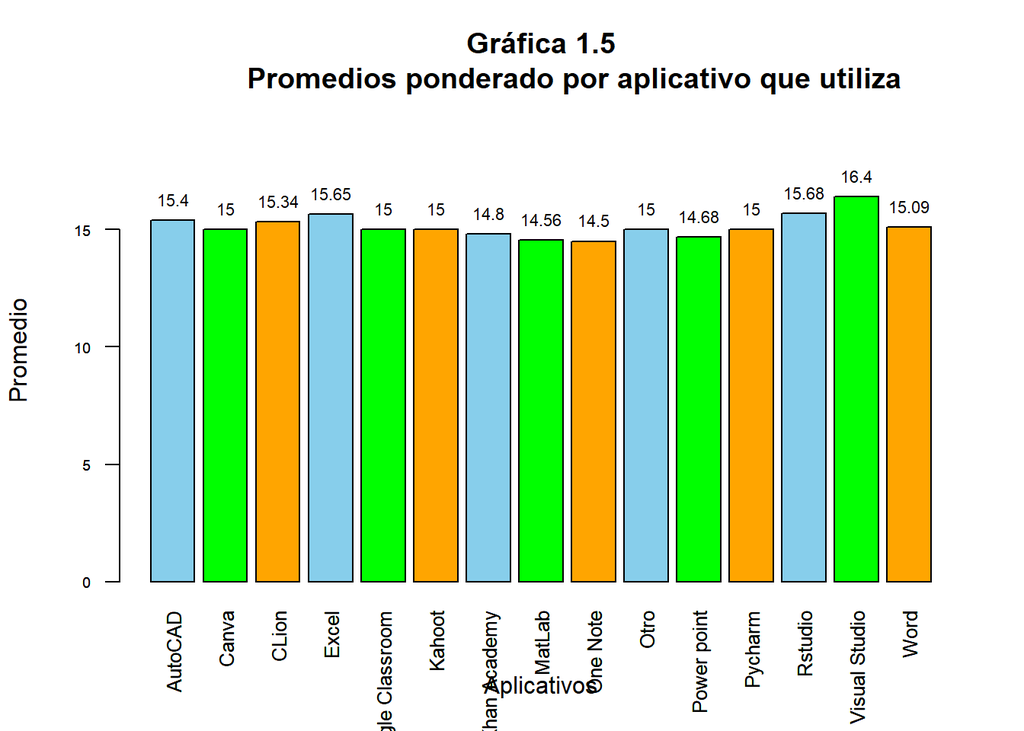

A partir de lo anterior podemos concluir que las aplicaciones que utilizan los estudiantes no influye en el promedio ponderado, por ende no existe una relación directa entre las aplicaciones que utiliza un alumno y la nota que puede sacar durante su carrera universitaria.

## Analisis 2:

*Analizar la relación entre la frecuencia de uso de los dispositivos tecnológicos por parte de los estudiantes y sus promedios ponderados*

variables que sirven para el análisis:

**Frecuencia de uso de los dispositivos**

**Promedios ponderados**

**Minutos que utilizan los dispositivos tecnológicos**

**Días a la semana en las que lo utiliza**

**-Análisis numérico:** realizaremos un análisis con descriptores numéricos para nuestras variables numéricas continuas.

- *Variable Promedio*

```r
summary(Datos$PROMEDIO)
```

```
##    Min. 1st Qu.  Median    Mean 3rd Qu.    Max.
##    5.00   14.33   15.00   15.17   16.00   20.00
```

```r
var(Datos$PROMEDIO,na.rm=T)  # Varianza
```

```
## [1] 2.778432
```

```r
sd(Datos$PROMEDIO,na.rm=T)   # Desviación estándar
```

```
## [1] 1.666863
```

```r
range(Datos$PROMEDIO) #Rango
```

```
## [1]  5 20
```

```r
mean(Datos$PROMEDIO,na.rm=T)  # Media o promedio
```

```
## [1] 15.16503
```

```r
CV1<-(sd(Datos$PROMEDIO,na.rm=T)/mean(Datos$PROMEDIO,na.rm=T))*100   # coeficiente de variación.
CV1
```

```
## [1] 10.99149
```

Interpretación:

-Tenemos como varianza un valor de 2.78.

-Tenemos un valor de desviación estándar de 1.67.

-Tenemos promedios con un rango desde 5 hasta 20.

-Tenemos un promedio de 15.17 de nota.

-Tenemos un coeficiente de variación de 10.99.

- *Variable Minutos*

```r
summary(Datos$MINUTOS)
```

```
##    Min. 1st Qu.  Median    Mean 3rd Qu.    Max.
##   100.0   180.0   300.0   297.3   380.0   960.0
```

```r
var(Datos$MINUTOS,na.rm=T)  # Varianza
```

```
## [1] 21623.1
```

```r
sd(Datos$MINUTOS,na.rm=T)   # Desviación estándar
```

```
## [1] 147.0479
```

```r
range(Datos$MINUTOS) #Rango
```

```
## [1] 100 960
```

```r
mean(Datos$MINUTOS,na.rm=T)  # Media o promedio
```

```
## [1] 297.3005
```

```r
CV2<-(sd(Datos$MINUTOS,na.rm=T)/mean(Datos$MINUTOS,na.rm=T))*100   # coeficiente de variación.
CV2
```

```
## [1] 49.46104
```

Interpretación:

-Tenemos como varianza un valor de 21623.1.

-Tenemos un valor de desviación estándar de 147.05.

-Tenemos minutos con un rango desde 100 hasta 960.

-Tenemos un promedio de 297.30 minutos.

-Tenemos un coeficiente de variación de 49.46.

- *Variable Días*

```r
summary(Datos$DÍAS)
```

```
##    Min. 1st Qu.  Median    Mean 3rd Qu.    Max.
##   2.000   5.000   7.000   6.104   7.000   7.000
```

```r
var(Datos$DÍAS,na.rm=T)  # Varianza
```

```
## [1] 1.510039
```

```r
sd(Datos$DÍAS,na.rm=T)   # Desviación estándar
```

```
## [1] 1.228836
```

```r
range(Datos$DÍAS) #Rango
```

```
## [1] 2 7
```

```r
mean(Datos$DÍAS,na.rm=T)  # Media o promedio
```

```
## [1] 6.103627
```

```r
CV3<-(sd(Datos$DÍAS,na.rm=T)/mean(Datos$DÍAS,na.rm=T))*100   # coeficiente de variación.
CV3
```

```
## [1] 20.13289
```

Interpretación:

-Tenemos como varianza un valor de 1.51.

-Tenemos un valor de desviación estándar de 1.23.

-Tenemos días con un rango desde 2 hasta 7.

-Tenemos un promedio de 6 días.

-Tenemos un coeficiente de variación de 20.13.

**Análisis comparativo entre el promedio y la frecuencia de uso de los dispositivos:**

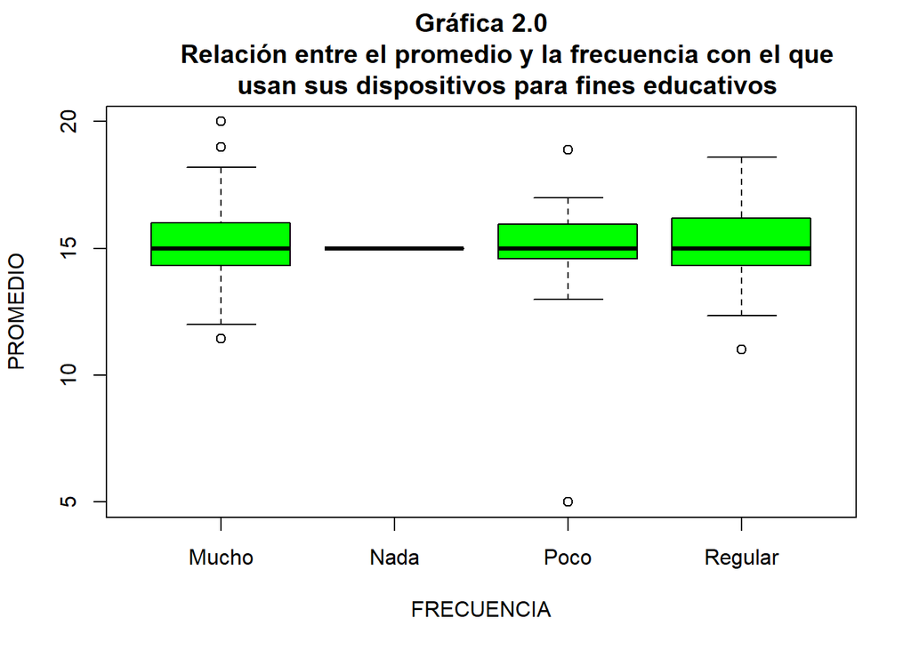

Observamos que el promedio para todas las frecuencias de uso de dispositivo son 15. Por lo que podemos concluir que si la frecuencia de uso de un dispositivo aumente no necesariamente habrá un aumento en el promedio de notas.

**Análisis de dispersión y correlación entre número de minutos al día que los estudiantes utilizan sus dispositivos para estudiar y los promedios ponderados de los estudiantes**

```r
cor(Datos$PROMEDIO,Datos$MINUTOS)
```

```
## [1] 0.1942437
```

Como observamos, el número de la correlación está lejos de ser 1, entonces podemos decir que existe una débil correlación positiva entre los minutos al día que los estudiantes utilizan sus dispositivos para estudiar y los promedios de los estudiantes. Para corroborar esto, realizamos un gráfico de dispersión y su regresión lineal:

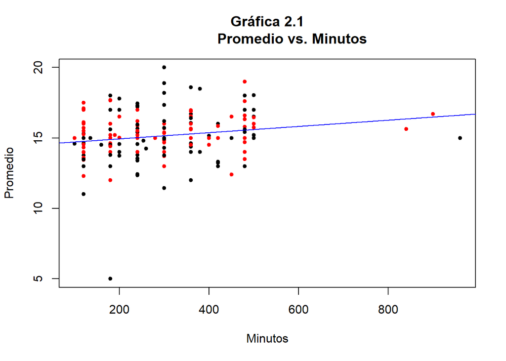

```r
lm(PROMEDIO ~ MINUTOS, data = Datos)
```

```
##
## Call:
## lm(formula = PROMEDIO ~ MINUTOS, data = Datos)
##
## Coefficients:
## (Intercept)      MINUTOS
##   14.510415     0.002202
```

```r
cor(Datos$PROMEDIO,Datos$DÍAS)
```

```
## [1] 0.05199805
```

Como observamos, el número de la correlación está lejos de ser 1, entonces podemos decir que existe una débil correlación positiva entre los días que los estudiantes utilizan sus dispositivos para estudiar y los promedios de los estudiantes. Para corroborar esto, realizamos un gráfico de dispersión y su regresión lineal:

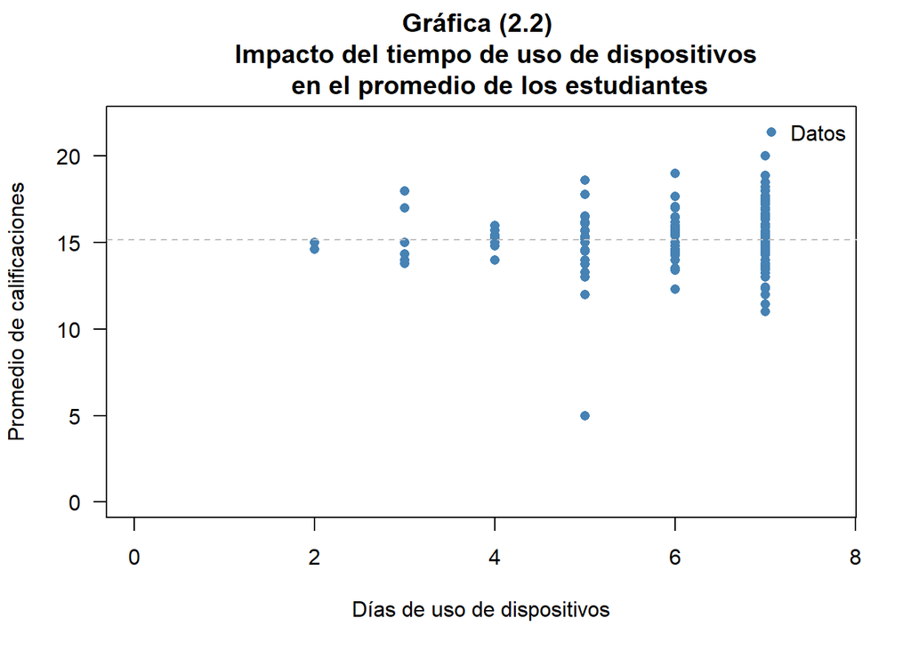

```r
lm(PROMEDIO ~ DÍAS, data = Datos)
```

```
##
## Call:
## lm(formula = PROMEDIO ~ DÍAS, data = Datos)
##
## Coefficients:
## (Intercept)         DÍAS
##    14.73452      0.07053
```

La función de la regresión lineal seria la siguiente:

$$y = 0.07053 x + 14.73452$$
Finalmente con todo los resultados podemos concluir que el tiempo, la frecuencia y los días en los que se utilizan los dispositivos tecnológicos para fines educativos no influye en los promedios que un estudiante pueda obtener.

## Analisis 3:

*Analizar si la cantidad de dispositivos tecnológicos que utilizan los estudiantes tiene alguna influencia en su desempeño académico*

variables que sirven para el análisis:

**Cantidad de dispositivos**

**Promedio ponderado**

**orden de merito**

[figure not shown]

```r
by(Datos$CANTDISPOSITIVOS,Datos$ORDENM,sd)
```

```
## Datos$ORDENM: Decimo superior
## [1] 0.9167638
## ------------------------------------------------------------
## Datos$ORDENM: Medio superior
## [1] 1.032796
## ------------------------------------------------------------
## Datos$ORDENM: Ninguno de los anteriores
## [1] 1.1939
## ------------------------------------------------------------
## Datos$ORDENM: Quinto superior
## [1] 0.9411239
## ------------------------------------------------------------
## Datos$ORDENM: Tercio superior
## [1] 0.9068212
```

De acuerdo con el gráfico de violín, se observan valores extremos que pueden sesgar el cálculo de la media, de igual manera la desviación estándar es alta en todos los casos. Por consiguiente, se emplea la mediana como la medida de tendencia central más adecuada en esta situación.

A partir del gráfico y la tabla podemos deducir que la cantidad de dispositivo que utilizan los estudiantes no influye en el orden de merito que pueda alcanzar. Esto sugiere que no existe una relación entre la cantidad de dispositivos y el orden de mérito, es decir, que tener más o menos dispositivos no garantiza un mejor o peor promedio ponderado y, por tanto, no influye en el orden de mérito.

```r
cor(Datos$CANTDISPOSITIVOS,Datos$PROMEDIO)
```

```
## [1] -0.06153321
```

Podemos observar que existe una correlación débil negativa entre el promedio ponderado y la cantidad de dispositivos lo que indica que si la cantidad de dispositivos aumenta no necesariamente aumentara el promedio ponderado.

```r
lm(PROMEDIO ~ CANTDISPOSITIVOS, data = Datos)
```

```
##
## Call:
## lm(formula = PROMEDIO ~ CANTDISPOSITIVOS, data = Datos)
##
## Coefficients:
##      (Intercept)  CANTDISPOSITIVOS
##          15.4677           -0.1041
```

La función de la regresión lineal seria la siguiente:

$$y = -0.1041 x + 15.4677$$
**Gráfico entre la cantidad de dispositivos y el promedio ponderado**

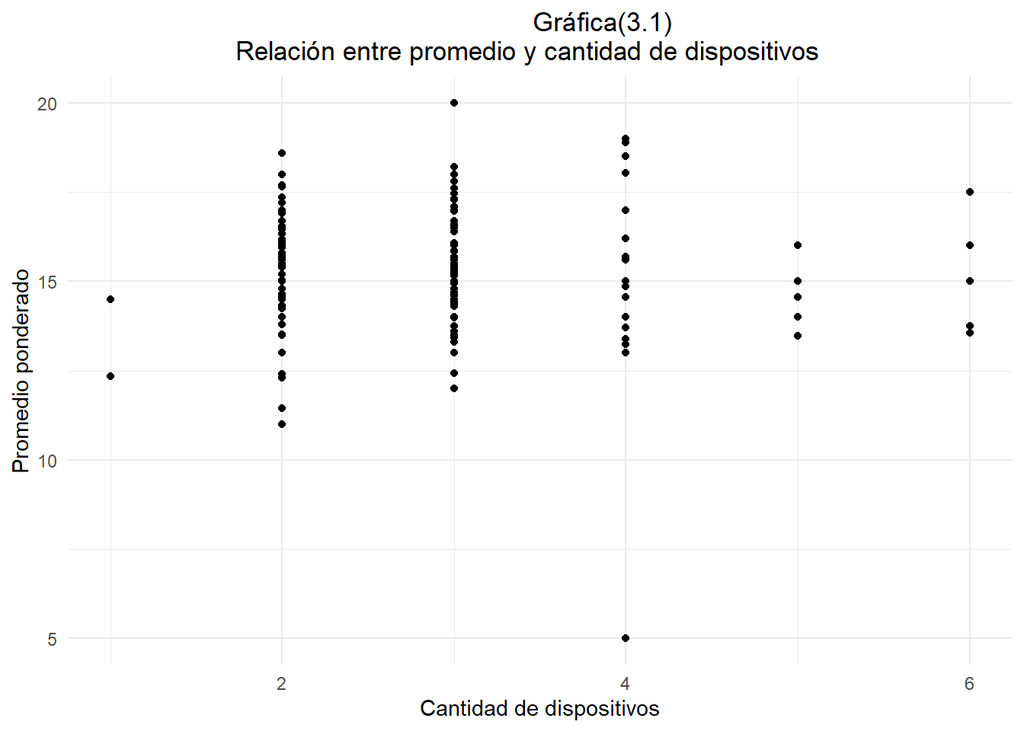

```r
by(Datos$PROMEDIO,Datos$CANTDISPOSITIVOS,median)
```

```
## Datos$CANTDISPOSITIVOS: 1
## [1] 13.42
## ------------------------------------------------------------
## Datos$CANTDISPOSITIVOS: 2
## [1] 15.42
## ------------------------------------------------------------
## Datos$CANTDISPOSITIVOS: 3
## [1] 15
## ------------------------------------------------------------
## Datos$CANTDISPOSITIVOS: 4
## [1] 15
## ------------------------------------------------------------
## Datos$CANTDISPOSITIVOS: 5
## [1] 14.78
## ------------------------------------------------------------
## Datos$CANTDISPOSITIVOS: 6
## [1] 14.375
```

A partir de la información anterior se concluye que la cantidad de dispositivos no influye de gran manera al promedio ponderado que se podría obtener.

## Analisis 4:

**Evaluar la satisfacción de los estudiantes al utilizar dispositivos tecnológicos en diferentes áreas académicas y analizar cómo esta satisfacción se relaciona con las calificaciones obtenidas**

variables que sirven para el análisis:

**Satisfacción al utilizar dispositivos tecnológicos**

**área académica**

**máxima nota obtenida en el área académica**

**Análisis de la moda y la frecuencia sobre la satisfacción y el área académica**

```r
Mode(Datos$SATISFACCIÓN)
```

```
## [1] Regular
## attr(,"freq")
## [1] 105
## Levels: Mucho Nada Poco Regular
```

```r
table(Datos$ÁREA, Datos$SATISFACCIÓN)
```

```
##
##                                                               Mucho Nada Poco
##   Ciencias Generales                                             25    1    9
##   Cursos de carrera                                              30    0    7
##   Cursos de gestión                                               1    0    0
##   Humanidades, Arte y Ciencias sociales(HACS)                     9    0    1
##   Proyectos Interdisciplinarios ,Tesis y Real life Experience     4    0    1
##
##                                                               Regular
##   Ciencias Generales                                               35
##   Cursos de carrera                                                46
##   Cursos de gestión                                                 5
##   Humanidades, Arte y Ciencias sociales(HACS)                      14
##   Proyectos Interdisciplinarios ,Tesis y Real life Experience       5
```

Podemos afirmar que la mayoría de los encuestados tiene una satisfacción regular por utilizar dispositivos tecnológicos para ciertas áreas académicas, asimismo podemos observar que en los curso de carreras y ciencia generales son donde se tiene mas participación de los dispositivos tecnológico, por consiguiente en las áreas de gestión y Proyectos Interdisciplinarios ,Tesis y Real life Experience la utilidad de los sispositivos tecnologicos disminuye considerablemente.

**Gráfico Área académica en el que se obtuvo mayor nota**

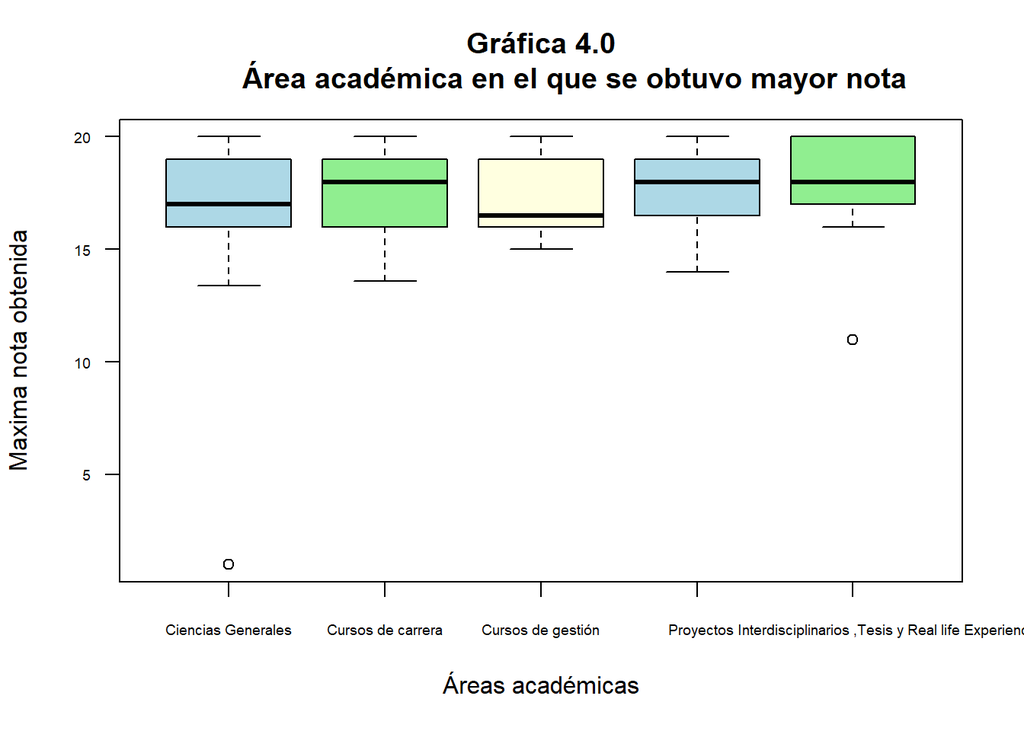

A partir de la gráfica anterior podemos observar que la máxima nota obtenida en una área académica al utilizar dispositivos electrónicos son demasiadas altas, en conclusión los dispositivos electrónicos son de utilidad para obtener notas altas en las diferentes área académicas.

**Gráfico Satisfacción de los dispositivos en los que se obtuvo mayor nota**

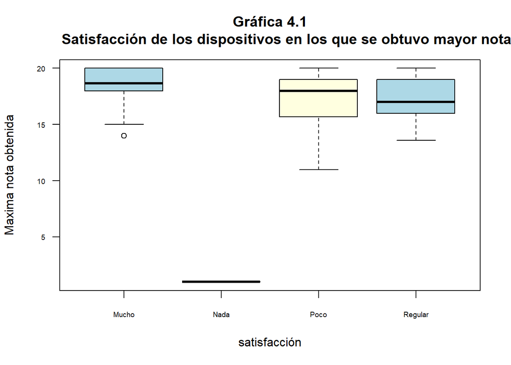

Del gráfico anterior podemos concluir que las personas que tienen una satisfacción **alta** al utilizar dispositivos electrónicos en ciertas áreas académicas tienen mejores notas a comparación de la personas que tienen un satisfacción **nada, poco y regular**. Asimismo podemos observar que la satisfacción que tienen los estudiantes al utilizar dispositivos electrónicos conllevan a conseguir notas altas.

## Analisis 5:

**Analizar la relación entre la marca del dispositivo preferido por los estudiantes y su coste, considerando el ciclo en el que se encuentran.**

A partir de nuestra base de datos extraemos las variables que serán importantes para el análisis anteriormente mencionado:

*Marca del dispositivo*

*Costo del dispositivo*

*ciclo que cursa*

*dispositivo que utiliza*

*promedio*

**Análisis de la moda respecto a la marca**

```r
Base_nueva <- Datos %>%
  mutate(MARCA = strsplit(MARCA, ",")) %>%
  unnest(MARCA)
```

```r
Mode(Base_nueva$MARCA)
```

```
## [1] "HP"
## attr(,"freq")
## [1] 57
```

**Análisis entre el precio de dispositivo y el promedio ponderado**

```r
cor(Datos$PROMEDIO,Datos$COSTO)
```

```
## [1] -0.009132336
```

Como observamos, el número de la correlación está lejos de ser 1 o -1, entonces podemos decir que existe una débil correlación negativa entre el costo del dispositivo electrónico que utiliza el estudiante para fines académico los promedios de los estudiantes. Para corroborar esto, realizamos un gráfico de dispersión y su regresión lineal:

[figure not shown]

```r
lm(PROMEDIO ~ COSTO, data = Datos)
```

```
##
## Call:
## lm(formula = PROMEDIO ~ COSTO, data = Datos)
##
## Coefficients:
## (Intercept)        COSTO
##   1.520e+01   -9.088e-06
```

**Análisis entre el marca del dispositivo y promedio ponderado**

[figure not shown]

**Análisis entre Ciclo y dispositivos**

```
##
##           Laptop Smartphone Tablet
##   Cuarto      47         34      7
##   Decimo       0          1      0
##   Noveno       3          0      0
##   Octavo       1          2      0
##   Primero      5          4      0
##   Quinto       6         10      1
##   Segundo     18          8      0
##   Septimo      2          6      0
##   Sexto        6          6      0
##   Tercero     13         11      2
```

A partir de la tabla anterior se observa que el ciclo no es importante para utilizar ciertos dispositivos debido a que los dispositivos que utilizan depende de la preferencia de cada uno de los estudiantes mas no al ciclo al cual pertenece.